# Multivariate Analysis of Variance (MANOVA)

Mathilde Marie Duville

# Description

The MANOVA may be used to (A) compare means on multiple outcomes between 2 or more groups. That is, we are interested in assessing whether the qualitative variable affects together various dependent variables. (B) Assess the linear relationship between various dependent and an independent variables.

# Notice

- This code is purely demonstrative. That is, data are not necessarily adequate for the analysis (e.g., a parametric test is applied when parametricity cannot be validated). Therefore, both data and outputs are not relevant and are not shared.
- Only parametric tests are presented here. If your data do not meet the assumptions for parametricity, a non-parametric approach may be used. Also, some advices are provided within each subsection that corresponds to the validation of parametric assumptions to manage their violation.

# One-way MANOVA

```r
rm(list = ls())

library(readxl)
data <- read_excel("One-way-MANOVA.xlsx")
```

## *MANOVA as a comparison of means on multiple outcomes between 2 or more groups.*

### Visualization

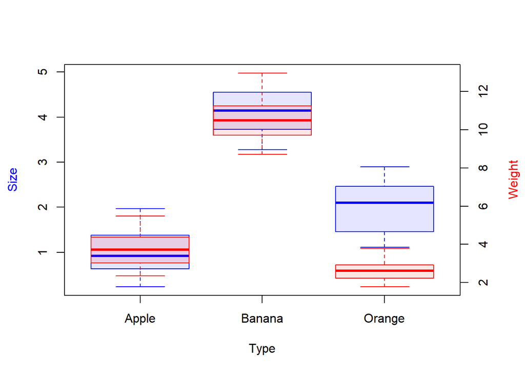

```r
par(mar = c(5, 4, 4, 4) + 0.3)
boxplot( data$Size ~ data$Type,
xlab="Type", ylab=" ",
col = rgb(0, 0, 1, alpha = 0.1),
border="blue")
par(new = TRUE)
boxplot(data$Weight ~ data$Type,
axes = FALSE,
col = rgb(1, 0, 0, alpha = 0.1),
border= "red", xlab = "", ylab = "")
axis(side = 4, at = pretty(range(data$Weight)))
mtext("Size", side = 2, line = 3, col="blue")
mtext("Weight", side = 4, line = 3, col="red")
```

```r
# Summary stats
library(rstatix)
data %>%  group_by(Type) %>% get_summary_stats(Size, Weight)
```

### Adequate sample size

Each group must have more samples than the number of response factors

```r
library(tidyverse)
data %>% group_by(Type) %>% summarise(N = n())
```

### Univariate outliers

Notice: The MANOVA may be run in presence of outliers. However, a sensitivity analysis must also be performed, that is, the analysis must be run again without extreme values to compare results.

```r
# Option 1
data %>% group_by(Type) %>% identify_outliers(Size)
data %>% group_by(Type) %>% identify_outliers(Weight)

# Option 2
boxplot.stats(data$Size)$out
boxplot.stats(data$Weight)$out

which(data$Size %in% boxplot.stats(data$Size)$out)
which(data$Weight %in% boxplot.stats(data$Weight)$out)
```

### Multivariate outliers

Unusual combination of outcome samples.

Notice: The MANOVA may be run in presence of outliers. However, a sensitivity analysis must also be performed, that is, the analysis must be run again without extreme values to compare results.

```r
data %>% group_by(Type) %>% mahalanobis_distance() %>%
 filter(is.outlier == TRUE) %>%  as.data.frame()
```

### Univariate normality

Notice: in case of violation of normality, you may run the MANOVA because this tend to be robust to non-normal distribution. However, you also perform a sensitivity analysis with transformed data that validate a normal distribution, and compare results.

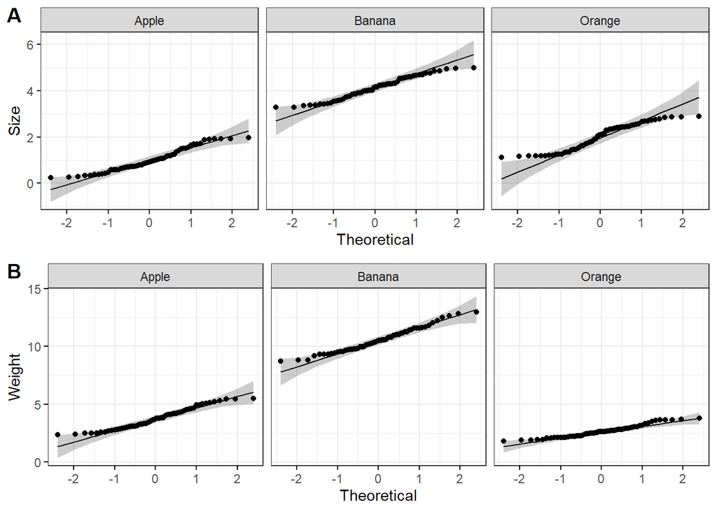

```r
# p>0.05 on Shapiro-Wilk
data %>% group_by(Type) %>%
  shapiro_test(Size, Weight) %>%  arrange(variable)

library(ggpubr)
p<-ggqqplot(data, "Size", facet.by = "Type", ylab = "Size", ggtheme = theme_bw())
p2<-ggqqplot(data, "Weight", facet.by = "Type", ylab = "Weight", ggtheme = theme_bw())
ggarrange(p, p2,labels = c("A", "B"),ncol = 1, nrow = 2)
```

NOTICE: Graphs may not be representative of the adequate conditions for normally distributed data. Codes are purely demonstrative to highlight the methodology. Dots of residuals must approximately fall along the reference line to validate normality.

### Multivariate normality

```r
# p>0.05 on Multivariate Shapiro-Wilk
data %>% select(Size, Weight) %>%  mshapiro_test()
```

### Multicollinearity

The dependency between dependent variables must be moderate (~ not > |0.9|). If too low, you may consider separate one-way ANOVAs.

```r
# In case of more than 2 dependent variables, use function "cor_mat"
data %>% cor_test(Size, Weight)
```